# Using RDataXMan Package

Sun Yinxiaohe, Ning Yilin, Mark Kevin Salloway

2017-07-27

## Folder Organisation

`RDataXMan` requires a specific folder structure for the functions to work:

```
Working directory
  |-- public_data
  |-- public_data_template
  `-- research
        |-- research folder1 (e.g., requestnum001)
              |-- private_data
              |-- private_data_template
              |-- request_input
              `-- request_output
        |-- research folder2
        `-- ...
```

## Workflow with `RDataXMan` package

The workflow using `RDataXMan` is illustrated using an arbitrary example.

### Step 1: Set working directory and research folder

This step creates the folder structure required by the package, as illustrated in the diagram above. Users may create the required subfolders manually, yet are highly recommended to use functions `initWkdir` and `initResearchFolder` for convenience.

User may select an existing folder as the working directory, or specify the directory to a new folder, in which case a new working directory will be created.

```r
library(RDataXMan)
initWkdir(wkdir = "Working directory")
initResearchFolder(wkdir = "Working directory", research.folder = "requestnum001")
```

After setting working directory and research folder, all public datasets that are saved as flat files should be stored in subfolder `public_data` of working directory, and all flat tables that are only meant to be accessible by this particular research project should be stored in subfolder `private_data` of selected research folder.

### Step 2: Generate the inclusion criteria and variable list

```r
genInclusion(wkdir = "Working directory", research.folder = "requestnum001",
             table_name, data.type, database,
             key.var, key.desc, identifier.var,
             count, overwrite,
             username, password, conn_string)
genVariable(wkdir = "Working directory", research.folder = "requestnum001",
            table_name, data.type, database,
            identifier.var, omit.var, overwrite,
            username, password, conn_string)
```

Parameter `data.type` should take value `public` or `private` if using flat tables, to indicate whether database is saved in `public_data` or `private_data` in the specified research folder. If linking to an actual database, `data.type` should be the type of database to link to, i.e. `ORE`, `Oracle` or `SQL`.

The Excel files generated by `genInclusion` and `genVariable` will be saved into  
`private_data_template` folder if `data.type` is `private`, and `public_data_template` otherwise.

After generating the request forms, users need to indicate their selection in each of the forms and save the modified copies in `request_input` folder within the research folder. See sections below for how to make selection in request forms. **Note that the package requires users to leave the original copy of request forms in the template folders.**

### Step 3: Extract data

After filling in all request forms and saving them in `request_input` folder, data extraction can be done using function `extract_data`:

```r
extract_data(wkdir = "Working directory", research.folder = "requestnum001",
             inclusion.xls.file, dataLogic, variable.xls.file,
             select.output, overwrite,
             username, password, conn_string)
```

`inclusion.xls.file` and `variable.xls.file` can be vectors if multiple inclusion criteria and/or variable lists are to be used for extraction. Users must specify `dataLogic` to be either `intersection` or `union` for multiple inclusion criteria.

`select.output` indicates output files to be generated by the function, where multiple selections can be indicated by a vector:

- `1`: generate lists of identifier variables from merged inclusion criteria.
- `2`: generate an Excel file with summary statistics for both inclusion criteria and variable lists.
- `3`: generate `csv` files with data extracted based on each request form.
- `4`: generate a single `csv` file for the final merged data.

Selected output files will be written into the `request_output` folder within the research folder, and meanwhile returned as a list of `data.frame`s in the R environment except for `2`.

In the final merged data, if there are multiple columns with the same name, each column name will be appended with the index of its corresponding variable list in the `variable.xls.file` argument.

## Things to note when filling in request forms

1. Do not modify the first row and the first column in “overall list” sheet, otherwise this will cause error in data extraction.
2. Do not modify the name of sheet “overall list”.
3. Names of request forms should not be changed when saved to `request_input` folder, and their file type should be “Excel 97-2003 Workbook” (i.e. with `xls` extension). Users are hence highly recommended to modify request forms and then use `Save As...` option of Excel to save the modified versions in `request_input` folder for convenience.

## Specifying Inclusion Criteria Using “overall list”

In this section we use an example to illustrate how to specify inclusion criteria by filling up the sheet “overall list” in long or short format.

Suppose we want to select all patients in a dataset as the starting cohort and eventually reduce the sample with other inclusion criteria. In this case, patient Id (denoted as patient NRIC in the example data) should be used as both key variable and identifier variable. There are two ways to specify such selection, one via the `selection` column of the request form, the other via the `logic` column.

### Using `selection` column

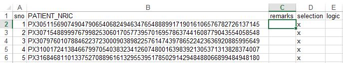

### Using `logic` column

Instead of going through each and every row to select all patients, users may also use R logical expression as a shortcut by writing `!is.na(PATIENT_NRIC)` in the first row of `logic` column, meaning that any row with a valid patient NRIC, effectively every row, should be selected:

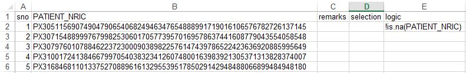

Users mush make sure that the logical statement specified is following valid R syntax, and need to pay attention to data type of key variable. For instance, `as.numeric(DIAGNOSIS_CD) >= 174 & as.numeric(DIAGNOSIS_CD) < 175` is advised instead of `DIAGNOSIS_CD >= 174 & DIAGNOSIS_CD < 175` if the inclusion criteria is to select any ICD code from 174.0 to 174.9, and users are not sure whether the column for ICD code is numeric. Note that only the first row of this column will be interpreted.

## Selecting Variable Using “overall list”

In this section we use an example to illustrate how to select variables for the final output by filling up the sheet “overall list” of variable list in long or short format.

To select specific variables listed in `variable` (Column B), put an `x`in the corresponding row in Column D, and leave Column D blank if a variable is not wanted.

Suppose we are interested in race, birth year and death indicator of patients, the sheet “overall list” of the variable list should be filled in the following way:

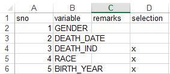